# NH3 Cattle

Lorenzo Benedetti

2026-03-17

# 1 Data import and preparation

The Excel file must contain the variables `TREATMENT`, `BLOCK`, and `N-NH3 perc TAN`. Each row must represent one independent experimental unit.

```r
data_file <- "Cattle Final NH3.xlsx"

if (!file.exists(data_file)) {
  stop("The file 'Cattle Final NH3.xlsx' was not found in the working directory.")
}

data <- read_excel(data_file)

required_columns <- c("TREATMENT", "BLOCK", "N-NH3 perc TAN")
missing_columns <- setdiff(required_columns, names(data))

if (length(missing_columns) > 0) {
  stop(
    "The following columns are missing from the Excel file: ",
    paste(missing_columns, collapse = ", ")
  )
}

data <- data %>%
  rename(NH3_TN = `N-NH3 perc TAN`) %>%
  mutate(
    TREATMENT = factor(TREATMENT),
    BLOCK = factor(BLOCK)
  )

if (anyNA(data[c("NH3_TN", "TREATMENT", "BLOCK")])) {
  warning(
    "Missing values are present in NH3_TN, TREATMENT, or BLOCK. ",
    "The model will use complete observations only."
  )
}
```

# 2 Experimental-design check

The following table shows the number of observations for each block-by-treatment combination. In a randomized complete block design, each cell should contain one observation.

```r
design_table <- with(data, table(BLOCK, TREATMENT, useNA = "ifany"))

kable(
  as.data.frame.matrix(design_table),
  caption = "Number of observations per block and treatment"
) %>%
  kable_styling(full_width = FALSE, position = "center")
```

Number of observations per block and treatment

| CSAA | CSH2SO4 | CSRAW |
| --- | --- | --- |
| 1 | 1 | 1 |
| 1 | 1 | 1 |
| 1 | 1 | 1 |

```r
if (any(design_table != 1)) {
  warning(
    "The design does not contain exactly one observation for each ",
    "BLOCK x TREATMENT combination. Because Type I sums of squares are ",
    "sequential, verify the data and model before interpreting the results."
  )
}
```

# 3 Descriptive statistics

The following values are unadjusted descriptive statistics. Block-adjusted estimated marginal means are reported below.

```r
desc <- data %>%
  group_by(TREATMENT) %>%
  summarise(
    mean = mean(NH3_TN, na.rm = TRUE),
    sd = sd(NH3_TN, na.rm = TRUE),
    n = sum(!is.na(NH3_TN)),
    se = sd / sqrt(n),
    .groups = "drop"
  )

kable(
  desc,
  digits = 3,
  caption = "Descriptive statistics by treatment"
) %>%
  kable_styling(full_width = FALSE, position = "center")
```

Descriptive statistics by treatment

| TREATMENT | mean | sd | n | se |
| --- | --- | --- | --- | --- |
| CSAA | 9.978 | 1.948 | 3 | 1.124 |
| CSH2SO4 | 9.957 | 2.394 | 3 | 1.382 |
| CSRAW | 15.552 | 0.841 | 3 | 0.485 |

# 4 Statistical model

Cumulative ammonia emissions are analysed according to a randomized complete block design using the model

$$Y_{ij} = \mu + \beta_j + \tau_i + \varepsilon_{ij},$$

where $\beta_j$ is the fixed effect of block, $\tau_i$ is the fixed effect of treatment, and $\varepsilon_{ij}$ is the residual error. Residuals are assumed to be independent and normally distributed with a mean of zero and constant variance. A block-by-treatment interaction is not included because only one observation is available for each block-by-treatment combination.

```r
# BLOCK is deliberately entered before TREATMENT.
model <- lm(NH3_TN ~ BLOCK + TREATMENT, data = data)

coefficient_table <- as.data.frame(summary(model)$coefficients)

kable(
  coefficient_table,
  row.names = TRUE,
  digits = 4,
  caption = "Coefficients of the linear model including block and treatment"
) %>%
  kable_styling(full_width = FALSE, position = "center")
```

Coefficients of the linear model including block and treatment

|  | Estimate | Std. Error | t value | Pr(>&#124;t&#124;) |
| --- | --- | --- | --- | --- |
| (Intercept) | 8.9236 | 1.2343 | 7.2294 | 0.0019 |
| BLOCK2 | 2.4466 | 1.3522 | 1.8094 | 0.1446 |
| BLOCK3 | 0.7166 | 1.3522 | 0.5300 | 0.6242 |
| TREATMENTCSH2SO4 | -0.0209 | 1.3522 | -0.0154 | 0.9884 |
| TREATMENTCSRAW | 5.5745 | 1.3522 | 4.1226 | 0.0146 |

## 4.1 Sequential Type I analysis of variance

Sequential Type I sums of squares are used. Because `BLOCK` is entered before `TREATMENT`, the treatment effect is tested after accounting for block. In a complete balanced block design, the treatment test is identical to the corresponding Type II test.

```r
anova_type1 <- anova(model)

kable(
  as.data.frame(anova_type1),
  row.names = TRUE,
  digits = 4,
  caption = "Sequential Type I ANOVA: block entered before treatment"
) %>%
  kable_styling(full_width = FALSE, position = "center")
```

Sequential Type I ANOVA: block entered before treatment

|  | Df | Sum Sq | Mean Sq | F value | Pr(>F) |
| --- | --- | --- | --- | --- | --- |
| BLOCK | 2 | 9.4923 | 4.7461 | 1.7306 | 0.2874 |
| TREATMENT | 2 | 62.3827 | 31.1913 | 11.3733 | 0.0224 |
| Residuals | 4 | 10.9701 | 2.7425 | NA | NA |

```r
model_information <- data.frame(
  observations = nobs(model),
  residual_df = df.residual(model),
  residual_sd = sigma(model),
  R_squared = summary(model)$r.squared,
  adjusted_R_squared = summary(model)$adj.r.squared
)

kable(
  model_information,
  digits = 4,
  caption = "Model information"
) %>%
  kable_styling(full_width = FALSE, position = "center")
```

Model information

| observations | residual_df | residual_sd | R_squared | adjusted_R_squared |
| --- | --- | --- | --- | --- |
| 9 | 4 | 1.6561 | 0.8676 | 0.7352 |

# 5 Estimated marginal means

Estimated marginal means are adjusted for the block effect and are reported with 95% confidence intervals.

```r
emm <- emmeans(model, ~ TREATMENT)

emm_results <- summary(
  emm,
  infer = c(TRUE, FALSE),
  level = 0.95
)

kable(
  as.data.frame(emm_results),
  digits = 3,
  caption = "Block-adjusted estimated marginal means with 95% confidence intervals"
) %>%
  kable_styling(full_width = FALSE, position = "center")
```

Block-adjusted estimated marginal means with 95% confidence intervals

| TREATMENT | emmean | SE | df | lower.CL | upper.CL |
| --- | --- | --- | --- | --- | --- |
| CSAA | 9.978 | 0.956 | 4 | 7.323 | 12.633 |
| CSH2SO4 | 9.957 | 0.956 | 4 | 7.303 | 12.612 |
| CSRAW | 15.552 | 0.956 | 4 | 12.898 | 18.207 |

# 6 Tukey-adjusted treatment contrasts

All pairwise comparisons are performed on the block-adjusted estimated marginal means. Tukey’s method is used to adjust both the P values and simultaneous 95% confidence intervals. No Fisher’s least significant difference test is used. The estimated mean differences and their confidence intervals are the primary effect sizes and measures of uncertainty.

```r
tukey_contrasts <- pairs(emm, adjust = "tukey")

contrast_results <- summary(
  tukey_contrasts,
  infer = c(TRUE, TRUE),
  level = 0.95,
  adjust = "tukey"
)

kable(
  as.data.frame(contrast_results),
  digits = 3,
  caption = paste(
    "Estimated treatment differences with simultaneous 95% confidence intervals",
    "and Tukey-adjusted P values"
  )
) %>%
  kable_styling(full_width = FALSE, position = "center")
```

Estimated treatment differences with simultaneous 95% confidence intervals and Tukey-adjusted P values

| contrast | estimate | SE | df | lower.CL | upper.CL | t.ratio | p.value |
| --- | --- | --- | --- | --- | --- | --- | --- |
| CSAA - CSH2SO4 | 0.021 | 1.352 | 4 | -4.798 | 4.840 | 0.015 | 1.000 |
| CSAA - CSRAW | -5.574 | 1.352 | 4 | -10.394 | -0.755 | -4.123 | 0.031 |
| CSH2SO4 - CSRAW | -5.595 | 1.352 | 4 | -10.414 | -0.776 | -4.138 | 0.031 |

# 7 Model diagnostics

Diagnostic tests have limited power with a small number of experimental units; therefore, their results should be interpreted together with the residual and influence plots.

```r
shapiro_res <- shapiro.test(residuals(model))

shapiro_table <- data.frame(
  test = "Shapiro-Wilk test on model residuals",
  statistic = unname(shapiro_res$statistic),
  p_value = shapiro_res$p.value
)

diagnostic_data <- data.frame(
  residual = residuals(model),
  treatment = model.frame(model)$TREATMENT
)

levene_res <- car::leveneTest(
  residual ~ treatment,
  data = diagnostic_data,
  center = median
)

kable(
  shapiro_table,
  digits = 4,
  caption = "Shapiro-Wilk test of residual normality"
) %>%
  kable_styling(full_width = FALSE, position = "center")
```

Shapiro-Wilk test of residual normality

| test | statistic | p_value |
| --- | --- | --- |
| Shapiro-Wilk test on model residuals | 0.8903 | 0.2011 |

```r
kable(
  as.data.frame(levene_res),
  row.names = TRUE,
  digits = 4,
  caption = "Levene's test applied to the model residuals"
) %>%
  kable_styling(full_width = FALSE, position = "center")
```

Levene’s test applied to the model residuals

|  | Df | F value | Pr(>F) |
| --- | --- | --- | --- |
| group | 2 | 0.8123 | 0.4873 |
|  | 6 | NA | NA |

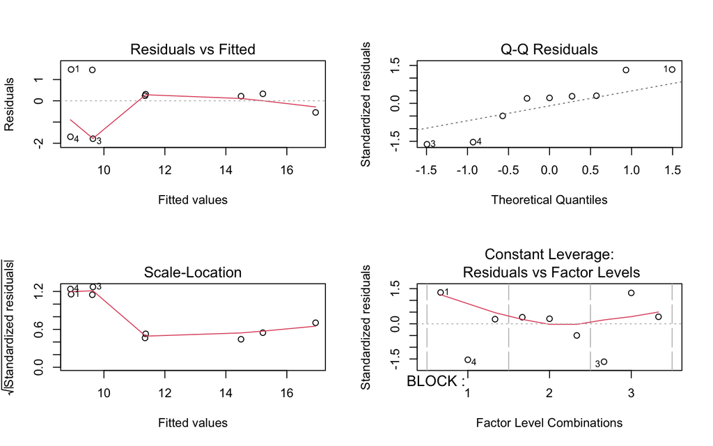

Diagnostic plots for the linear model

```r
par(mfrow = c(2, 2))
plot(model)
```

```r
par(mfrow = c(1, 1))
```

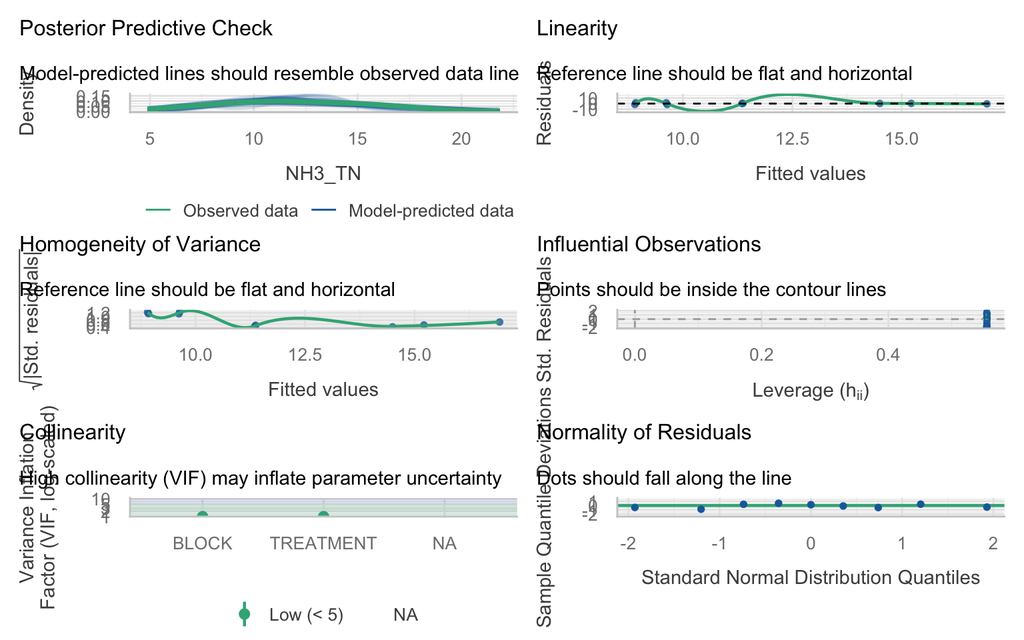

Graphical assessment of model assumptions

```r
check_model(model)
```

# 8 Data representation by block

Lines connect observations belonging to the same block, showing the matched structure of the experimental design.

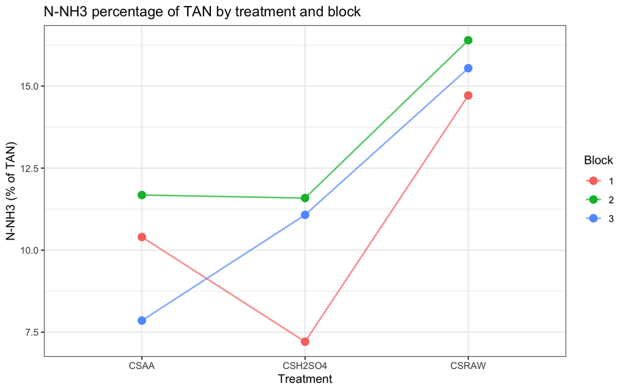

Observed treatment values distinguished by block

```r
ggplot(
  data,
  aes(
    x = TREATMENT,
    y = NH3_TN,
    group = BLOCK,
    colour = BLOCK
  )
) +
  geom_line(linewidth = 0.7, alpha = 0.7) +
  geom_point(size = 3) +
  theme_bw() +
  labs(
    x = "Treatment",
    y = "N-NH3 (% of TAN)",
    colour = "Block",
    title = "N-NH3 percentage of TAN by treatment and block"
  )
```

# 9 Estimated marginal means and confidence intervals

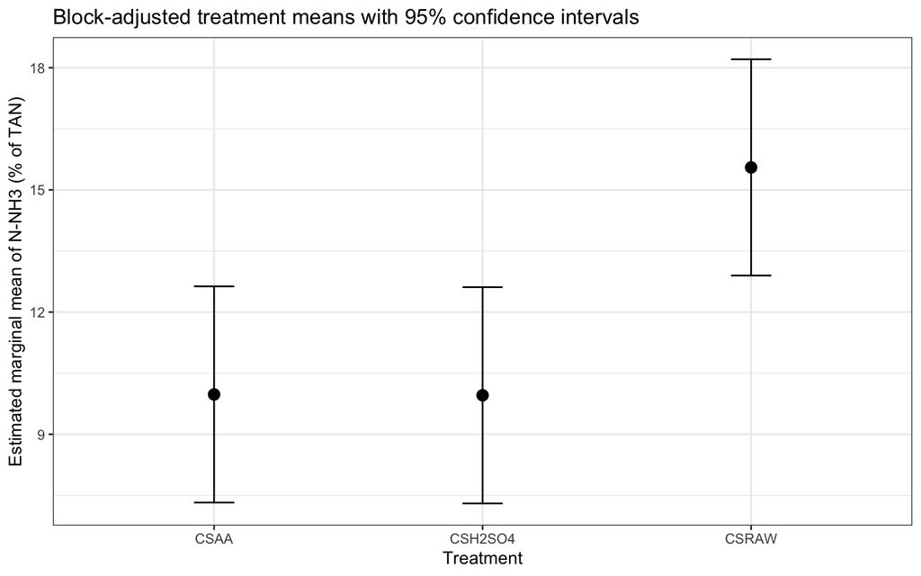

Block-adjusted estimated marginal means and 95% confidence intervals

```r
emm_plot_data <- as.data.frame(emm_results)

ggplot(
  emm_plot_data,
  aes(x = TREATMENT, y = emmean)
) +
  geom_point(size = 3) +
  geom_errorbar(
    aes(ymin = lower.CL, ymax = upper.CL),
    width = 0.15
  ) +
  theme_bw() +
  labs(
    x = "Treatment",
    y = "Estimated marginal mean of N-NH3 (% of TAN)",
    title = "Block-adjusted treatment means with 95% confidence intervals"
  )
```